# Red Wine Exploratory Data Analysis by Niall O’Riordan

# Introduction.

The data set explored contains tidy data about red wine samples. It contains 1599 observations of 11 input variables (chemical make-up based on physico- chemical tests) and one output variable (quality). The output is based on sensory data; the median of at least 3 evaluations made by wine experts on a scale of 0 (bad) to 10 (good). More information can be found in the file descriptions.txt.

# Initial Analysis.

The first thing I did was run ggpairs() on the dataset (excluding X and q.cat), in order to get the correlation figures for all the pairs. This can be referenced below in the Bivariate Analysis section.

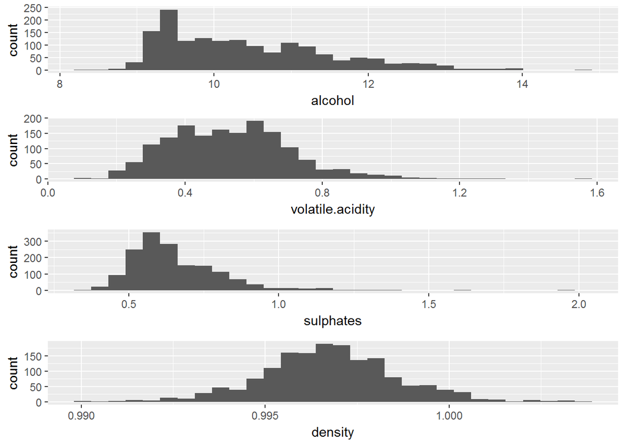

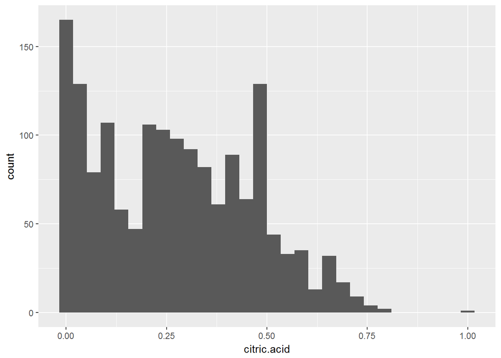

I don’t think there’s many insights to be gained from the univariate plots.  
Most seem to have very small ranges and are very left sided. Alcohol seems to have a slightly broader range and I’ll be investigating this relationship later.

Perhaps one interesting plot is the citric acid plot above. There seems to be a large amount of wines with low levels of citric acid. This might explain the low correlation number; it’s not so much that quality wines have a low level of citric acid, as almost all the wines have a low level of citric acid.

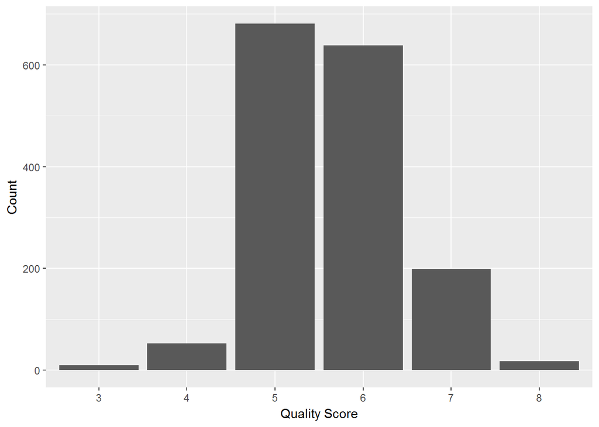

Before moving on to the next section, I’m going to add a “q.cat” variable to the dataset, with values “good” for wines rated 7-10, “fair” for “5-6”, and “poor” for the rest. I think most users won’t care about the specific rating of a wine, only whether it’s a good wine or not.

I had planned on using the values 8-10 for “good”, but looking at the histogram above, it seems there’s few wines in this category. This raises some questions about the dataset. The vast majority of wines were in the 5-6 range. This can possibly be explained by the similarity of the wines being sampled. I also wonder how the wines were rated, and if there was an outside influence on the judges? For example, for the purposes of this project I saw no issue with categorising some wines as “poor”, but if the wine producers were present during the rating, the judges may have been reluctant to rate the wine poorly.

I considered removing the “X” variable as it seems pretty redundant. I decided to keep it in case I sort the dataframe later and want to return it to it’s original order.

As can be seen below, categorising the wines makes the lack of variety in the quality ratings even more apparent.

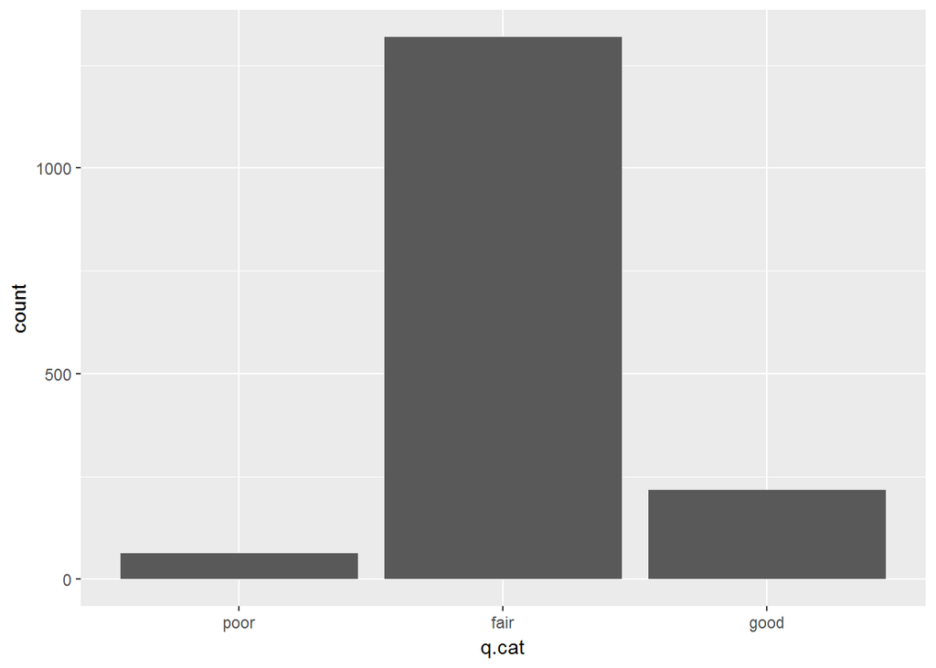

# Bivariate Analysis

I’ll start by running ggpairs() to try and get a feel for the relationships between the variables. I’ve included the pdf ggpairsplot.pdf because the output below may be difficult to see. The univariate plots appear on the diagonal, with bivariate plots below.

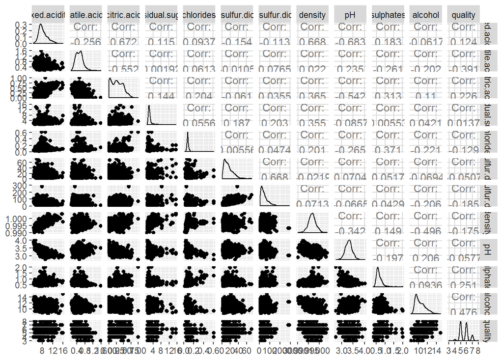

I didn’t expect this to be very useful, and in my opinion it has turned out not to be. We’re only interested in what chemicals affect the quality rating of the wine, so graphing the rest of the relationships is pretty much a waste of time. The plots on the horizontal ‘quality line’ are also don’t’ seem very useful. All have discrete horizontal lines due to the 1-10 discrete quality scale, and all seem to have relatively wide distributions. All also seem to suffer from over plotting. I may try to reduce that to get more useful graphs later.

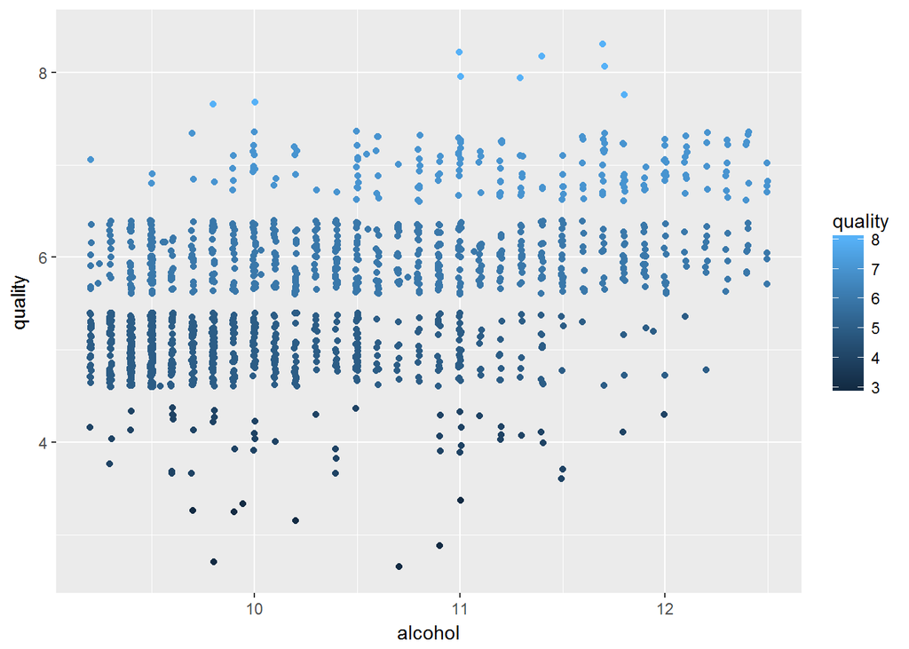

Above scatter plot doesn’t seem very useful. Comparing the light blue to the dark, it is possible to see more light blue (high quality) observations at higher alcohol levels, but maybe I should do a box plot instead.

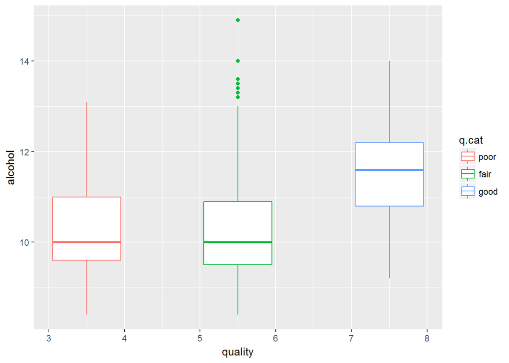

The box plot above makes the correlation between quality and alcohol much easier to see. To the judges linking quality and alcohol could be subconscious, though as we can see from some of the outliers in the “fair” it’s not universal. I’ve read that some scientists theorise that our brains respond in a similar way to alcoholic sugars as regular sugar, so I kind of expected this.

I am surprised how close the “fair” and “poor” categories are, and expected a more linear progression. Some summary statistics are below, but don’t seem to reveal much. I’d hoped to explore this further, wondering if a combination of chemicals makes the difference between “good” wines with high alcohol content and “fair” wines with high alcohol content, but didn’t spend the time on it.

Summary of Alcohol Content (poor wines).

```
##    Min. 1st Qu.  Median    Mean 3rd Qu.    Max.
##    8.40    9.60   10.00   10.22   11.00   13.10
```

Summary of Alcohol Content (fair wines).

```
##    Min. 1st Qu.  Median    Mean 3rd Qu.    Max.
##    8.40    9.50   10.00   10.25   10.90   14.90
```

Summary of Alcohol Content (good wines).

```
##    Min. 1st Qu.  Median    Mean 3rd Qu.    Max.
##    9.20   10.80   11.60   11.52   12.20   14.00
```

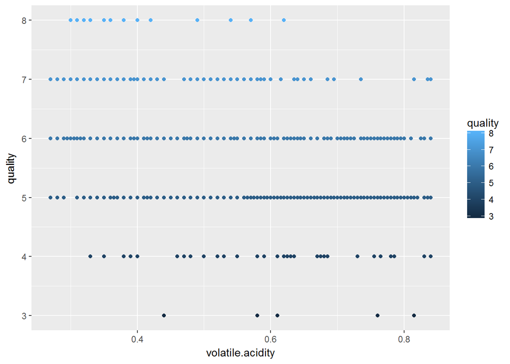

Again, the above scatter plot doesn’t seem very useful. It’s possible to see a lot more light blue observations at lower volatile acidity levels than dark blue, but I think I’ll do a box plot again.

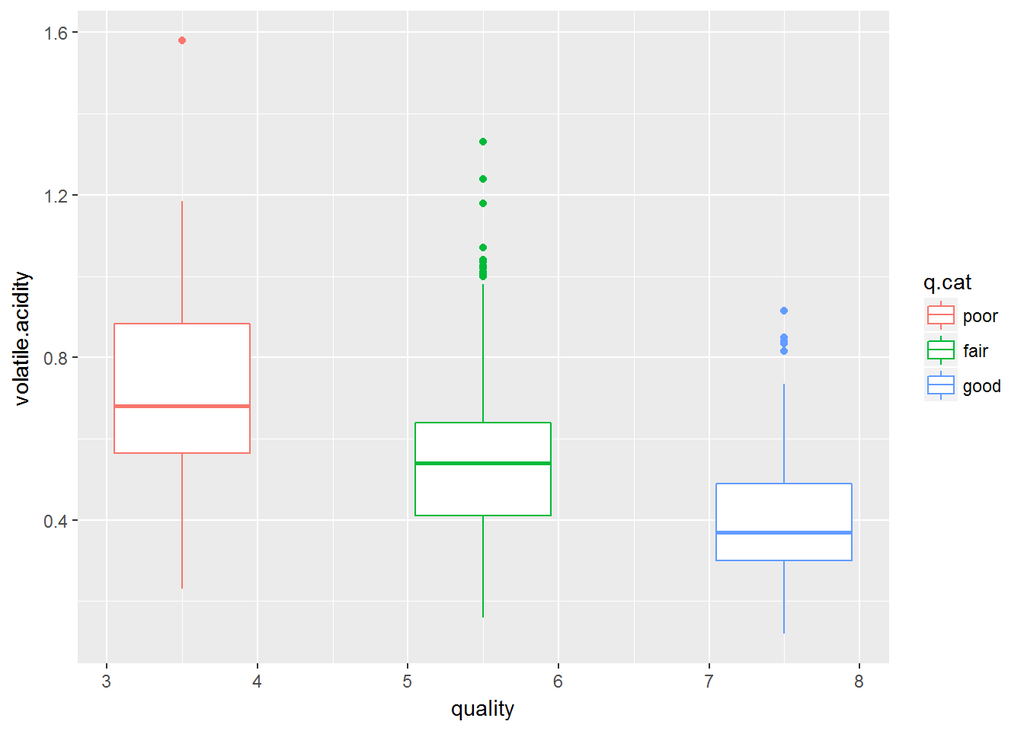

Summary of Volatile Acidity (poor wines).

```
##    Min. 1st Qu.  Median    Mean 3rd Qu.    Max.
##  0.2300  0.5650  0.6800  0.7242  0.8825  1.5800
```

Summary of Volatile Acidity (fair wines).

```
##    Min. 1st Qu.  Median    Mean 3rd Qu.    Max.
##  0.1600  0.4100  0.5400  0.5386  0.6400  1.3300
```

Summary of Volatile Acidity (good wines).

```
##    Min. 1st Qu.  Median    Mean 3rd Qu.    Max.
##  0.1200  0.3000  0.3700  0.4055  0.4900  0.9150
```

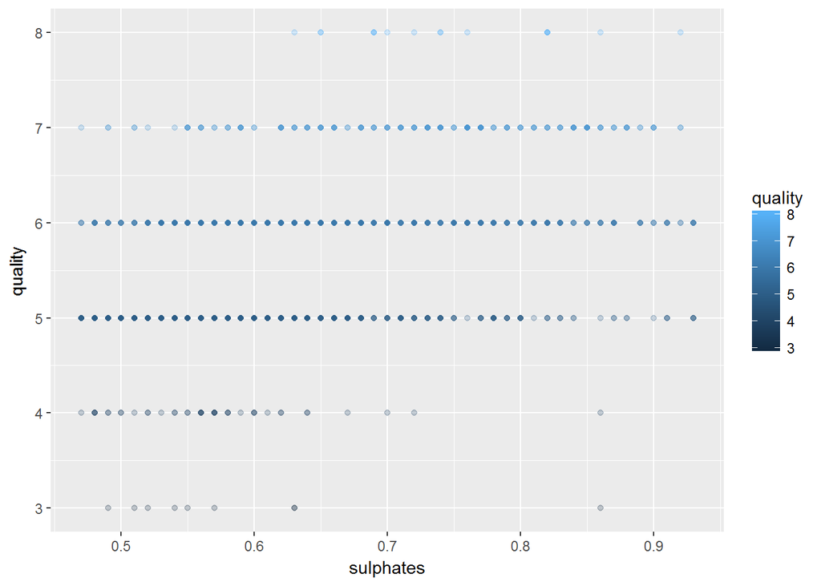

The above scatter plot shows the relationship between sulphates and quality. I’ve attempted to make this plot more readable by introducing an alpha level of 1/4. This helps, but the vast amount of average observations still present make the effect of quality increasing as sulphates do hard to see.

In the box plot below I think the relationship is again easier to see. This time I’ve also taken off the top and bottom 5% of sulphate observations to make the interquartile range appear bigger. It’s worth noting though how small the variance in levels is.

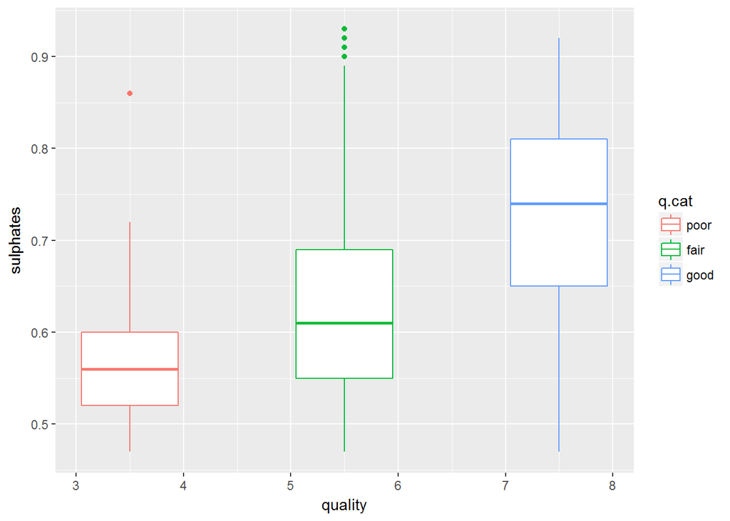

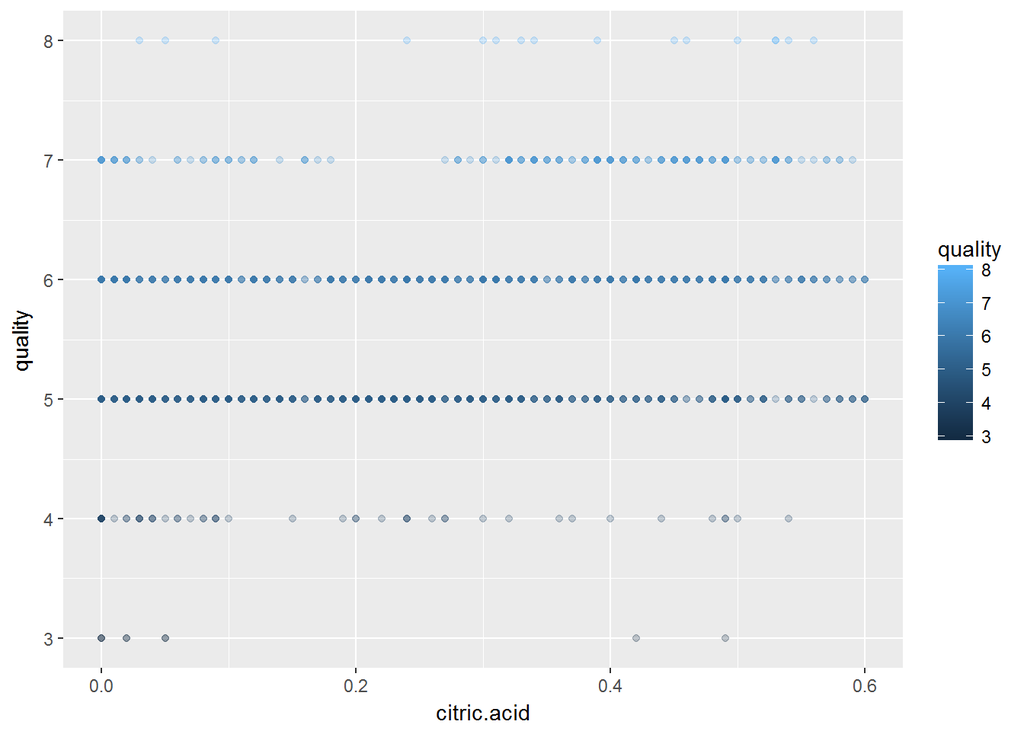

The above scatter plots show the relationship between citric acids and quality. Like the previous plots I’ve attempted to make this plot more readable by introducing an alpha level of 1/4. This again makes the higher number of light blue observations at higher citric acid easier to see, but is still somewhat masked by the large amount of average quality observations.

In the box plot below I think the relationship is again easier to see. This time I’ve again taken off the top and bottom 5% of citric acid observations to make the interquartile range appear bigger. It’s worth noting again how small the variance in levels is.

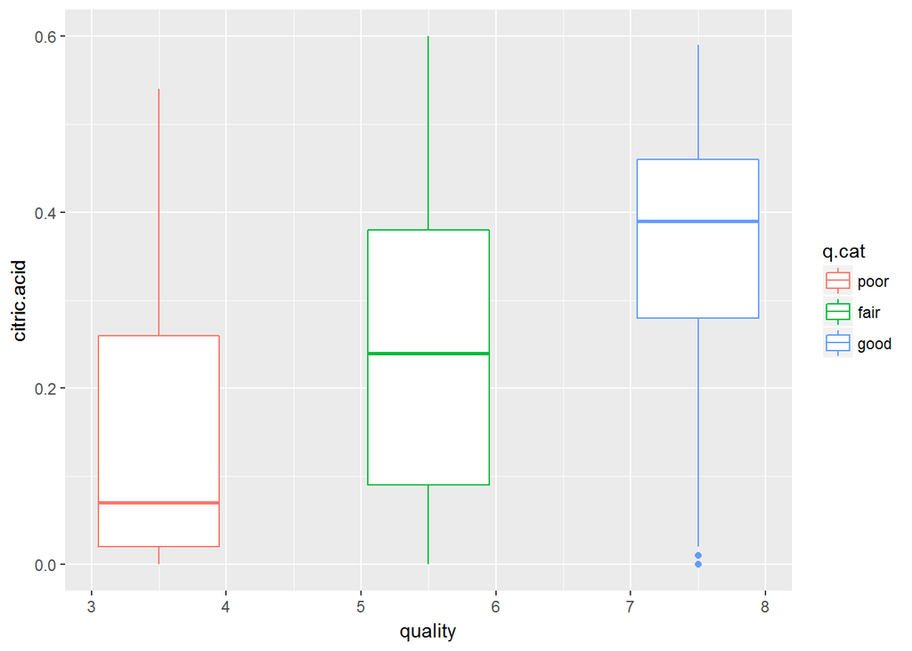

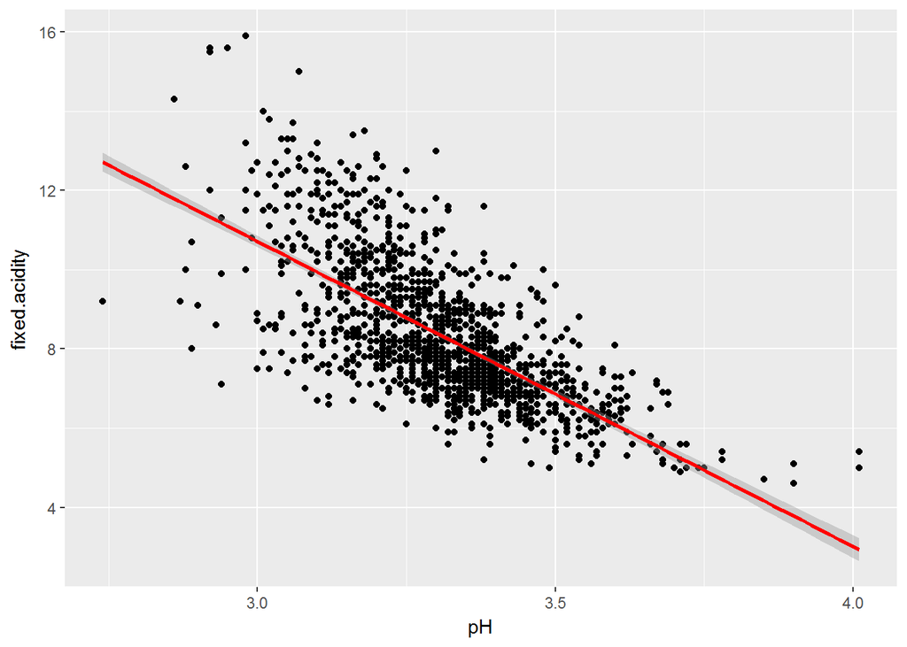

I was surprised by the residual sugar content having little effect on the quality of the wine. Like the alcohol content, I expected the judges to have a subconscious reaction to the sugar. It appears from the graph below that the residual sugar levels in almost all the wines are pretty low, and drop off for the very high quality wines.

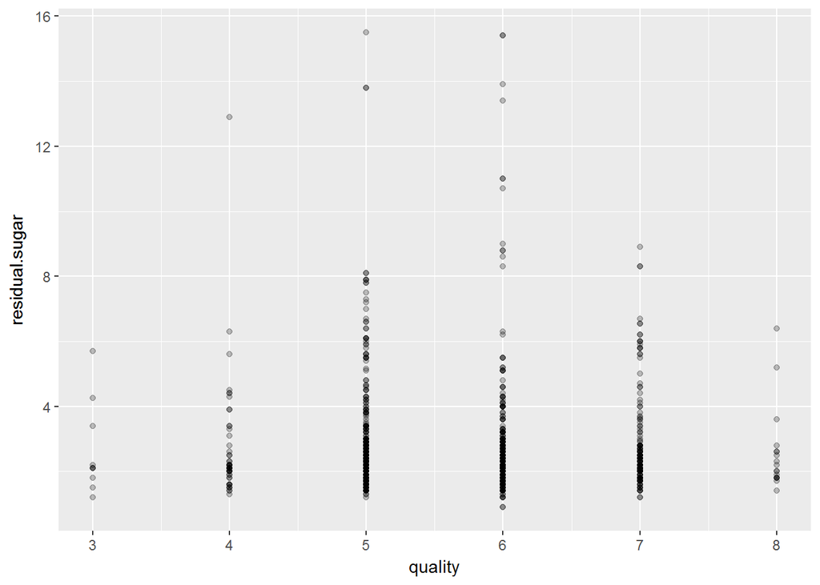

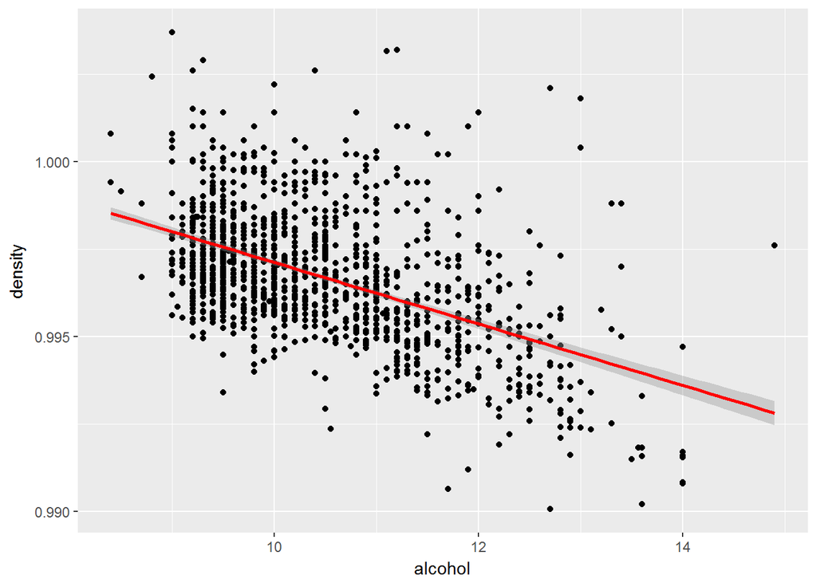

# Multivariate Analysis

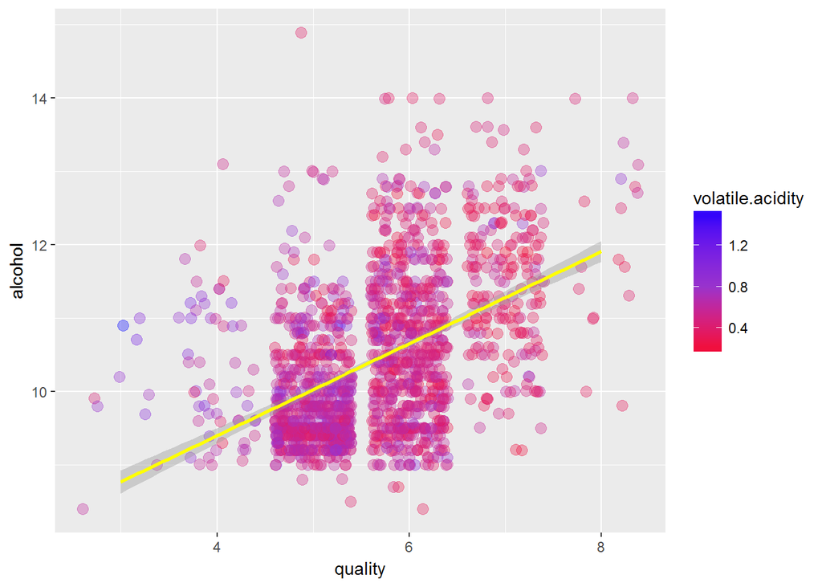

The above plot is a bit noisy, but I think shows the main relationships that affect wine quality. The yellow line shows a general upward trend for quality increasing as alcohol increases. We can also see a lot more blue (high vol- atile acidity at the left hand side of the plot, indicating acidity decreases as quality increases. I’ve added jitter to this plot and the next few to try and make the scale look a bit more continuous.

We can see similar effects with sulphates below. Sulphates help prevent a wine oxidising, so as expected we see quality increase as sulphates do. This affect is limited though as too much sulphates results in a wine that is too dense.

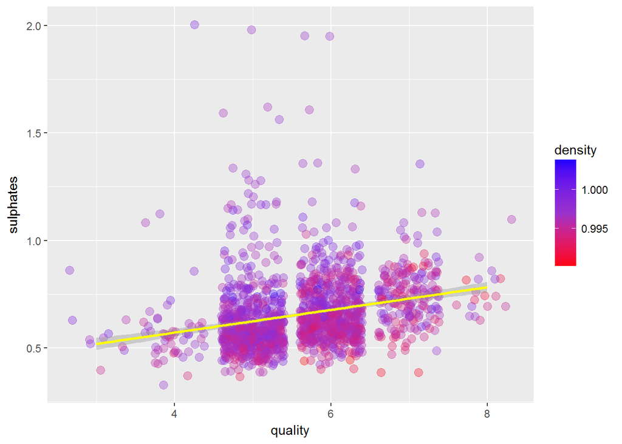

Similar effects can also be seen with citric acids below. They are said to add “freshness” to wine, but are illegal to add to wine in the EU except in specific circumstances. I had hoped to do more analysis of this, but the citric acid levels are so low, I don’t think it’s worth continuing.

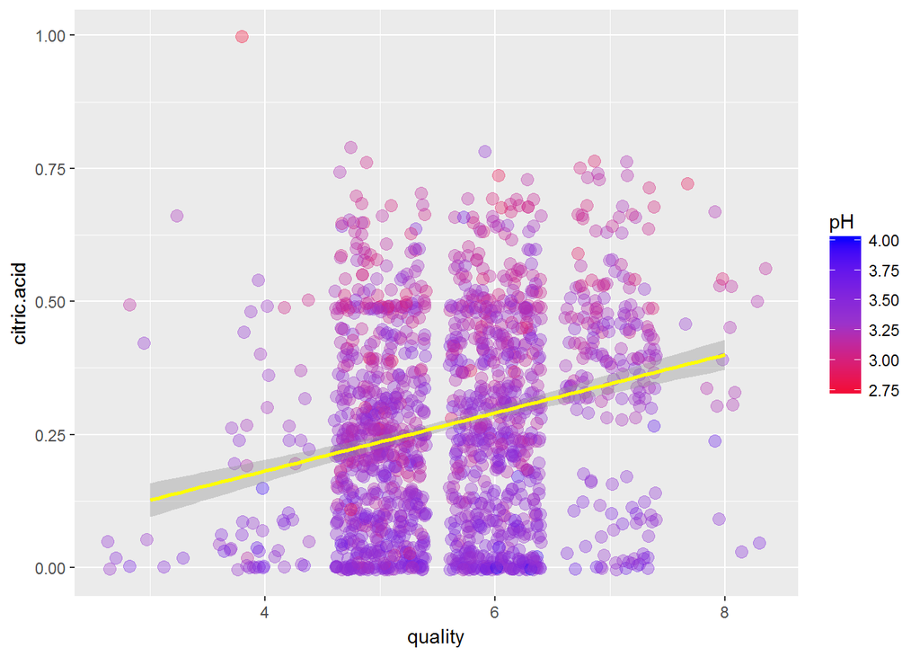

# Final Plots and Summary

I think these are the three most useful plots that I found :

### Plot One

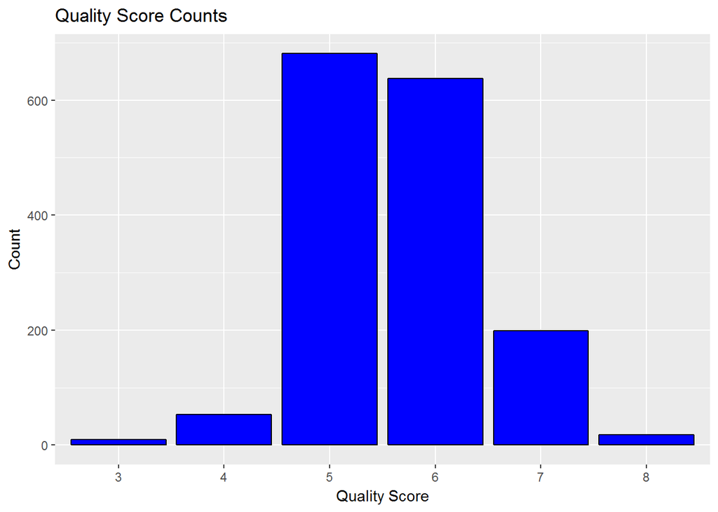

### Description One

The first plot is a simple histogram of the quality ratings. This shows some of the limitations of the data set. The ratings for quality are discrete, rather than continuous. There’s also a disparate number of ‘average’ ratings in the 5-6 range. The similarity of quality observations might be in part explained by the fact that all the observations are of the Portuguese “Vinho Verde” red wine.

It’s worth noting also that there are only six different scores observed which I’ve divided into three quality categories. Wines that scored 3 or 4 are in the “poor” category, wines that scored 5 or 6 are in the “fair” category, and wines that scored 7 or 8 are in the “good” category.

### Plot Two

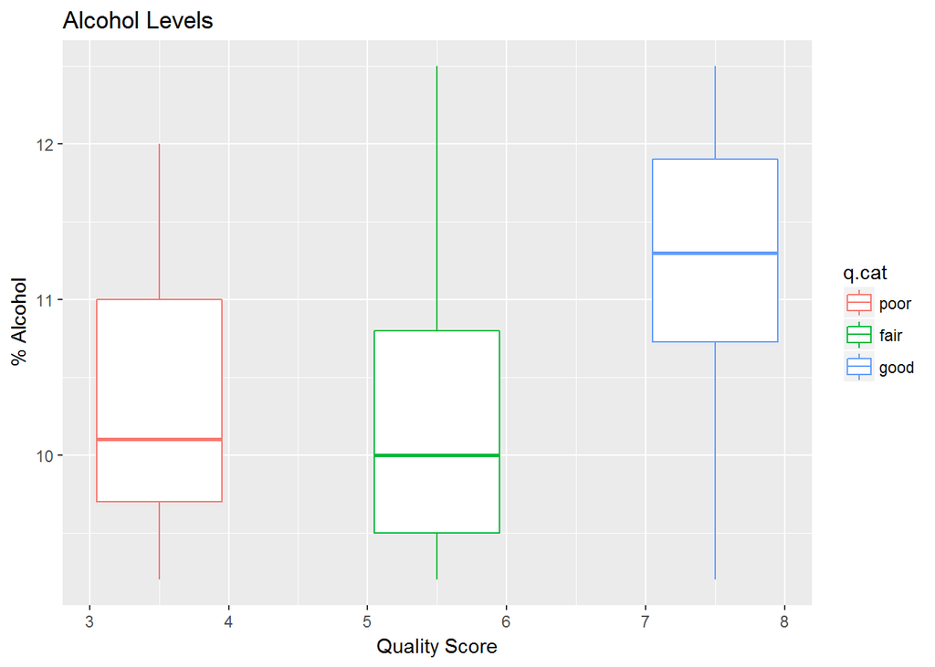

### Description Two

This is similar to the earlier box plot of alcohol vs quality. I’ve cut off the top and bottom 5% of outliers to better show the relationship. This makes it easier to see the interquartile alcohol range of the “good” quality wines is higher than “fair”" or “poor”.

### Plot Three

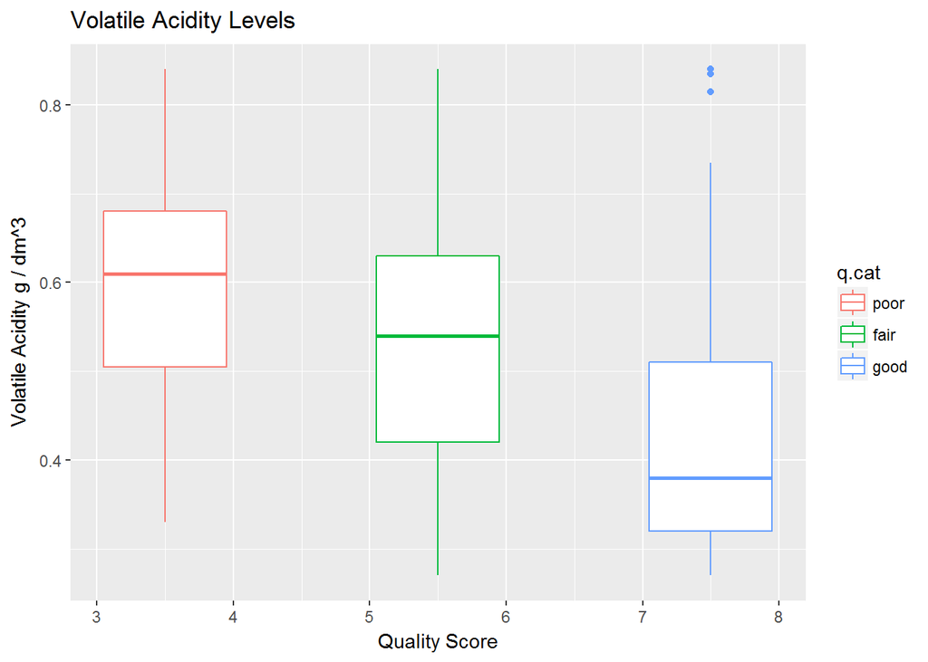

### Description Three

This is again similar to the earlier box plot of volatile acidity vs quality. I’ve cut off the top and bottom 5% of outliers to better show the relationship. This makes it easier to see the interquartile volatile acidity range of the “good”" quality wines is lower than “fair”" or “poor”.

Volatile acidity has a negative correlation of -0.391 with quality which is small but meaningful; as volatile acidity levels go down, quality scores generally go up. This effect seems more linear than what we see with alcohol. The mean volatile acidity level of “poor” wines is .72, the mean for “fair” wines is .54, and the mean for “good” wines is .4.

# Reflection

The dataset is relatively small with relatively few inputs, so it was easy to identify the main variables that affect the quality rating. The largest was alcohol with a moderate correlation. The next largest was volatile acidity with a small but meaningful correlation.

The dataset itself isn’t very diverse. The majority observations are at average quality levels and the quality scores themselves are discrete integers. I’ve used jitter in some of the plots to try and make the relationships seem more linear. I also added a quality category (q.cat) variable to separate quality scores into ranges. Not only do I think most people would be more interested in what category a wine is in rather than a numeric score, but I feel this made it easier to see the relationships between the variables.

This project is already overdue, but I wish I had more time to explore the data. I’d have liked to explore the main inputs (alcohol and volatile acidity) that affected quality more. I believe I would have needed to research the other inputs themselves more, to see if I could find information on how they typically affect each other. Some relationships are obvious (e.g. : residual sugar and density), but the relationship between sulphates, SO2 and acidity levels could be more complex, and combine to affect the quality rating.

In the future I’d like to explore larger data sets with more diverse wines. Though I’m unsure if I’d find the same insights, I feel this dataset was very limited in it’s scope, and if I had developed a prediction model from it, I would worry that it would only be applicable to the type of wine studied. I think it would also be more useful to introduce a more continuous quality rating scale. The ratings are described as an average of ratings by 3 or more experts; there must have been some detail lost in the process.